# CrimeMD

## Reading in the Data

We load up all the libaries we plan on using for this dataset and load in the crimemd csv from my files.

```r
library(readr)
library(dplyr)
```

```r
library(ggplot2)
library(DT)
library(ggrepel)
library(leaflet)
library(janitor)
library(MASS)
library(scales)
library(lubridate)
setwd("C:/Users/Jeffo/Downloads")
crimemd<- read.csv('crimemd.csv')
crimemd <- crimemd%>%
  clean_names()
```

## Cleaning the Data

Before we start to anaylze the data, we need to clean the data first in order have to data to be more user friendly.

### Renaming some variables for easier reading

```r
colnames(crimemd)[36] <- "b_e_percent_change"
colnames(crimemd)[20] <- "overall_percent_change"
colnames(crimemd)[22] <- "violent_crime_rate_change"
```

### using the lubridate package, get date and year

```r
date<-as.Date(crimemd$year,'%m/%d/%Y')
year<-as.numeric(format(date,'%Y'))
crimemd$date<- date
crimemd$year<- year
```

## Exploratory Anaylsis

```r
sort(crimemd$population)
```

```
##  [1] 4098000 4139000 4143000 4144000 4149000 4192211 4261000 4265000
##  [9] 4304000 4349000 4392000 4463000 4535000 4644000 4694000 4781468
## [17] 4860000 4908000 4965000 5006000 5042000 5072000 5094000 5135000
## [25] 5172000 5296486 5375156 5458137 5508909 5558058 5600388 5615727
## [33] 5618344 5633597 5699478 5773552 5828289 5884563 5928814 5976407
## [41] 6006401 6016447
```

### 5 Number summary for population

Using the 5 number summary, we are able to see that the Minimum population is 4098000. The Maximum population is 6016447

```r
summary(crimemd$population)
```

```
##    Min. 1st Qu.  Median    Mean 3rd Qu.    Max.
## 4098000 4409750 5057000 5037772 5611892 6016447
```

## Boxplot for Population

I made a boxplot for population in order to see the population statstics a bit easier.

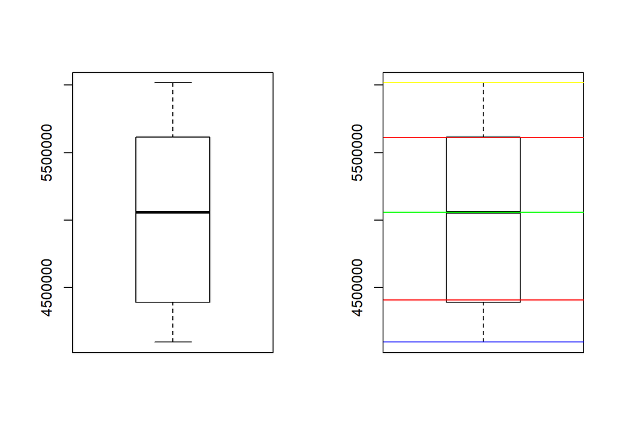

```r
par(mfrow = c(1, 2))
boxplot(crimemd$population)
boxplot(crimemd$population)


abline(h = min(crimemd$population), col = "Blue")

abline(h = max(crimemd$population), col = "Yellow")

abline(h = median(crimemd$population), col = "Green")

abline(h = quantile(crimemd$population, c(0.25, 0.75)), col = "Red")
```

## Focusing on Breaking and Entering

Since our project is mainly focusing on burglary, breaking and entering is the closest there is to that.

```r
sort(crimemd$b_e)
```

```
##  [1] 24822 26741 28175 31889 33472 35781 35921 36682 36700 36905 37095
## [12] 37457 38641 38849 39654 39721 42799 43629 47235 47839 50316 51498
## [23] 52225 52697 52698 53168 53226 53311 53537 54696 55521 55596 56237
## [34] 56255 56351 57936 57938 58901 60547 62657 70762 71130
```

## 5 number summary for Breaking and Entering

We can see that the minumum for breaking and entering occurences is 24822. The max is 71130.

```r
summary(crimemd$b_e)
```

```
##    Min. 1st Qu.  Median    Mean 3rd Qu.    Max.
##   24822   37186   50907   47315   55577   71130
```

## Boxplot for Breaking and Entering

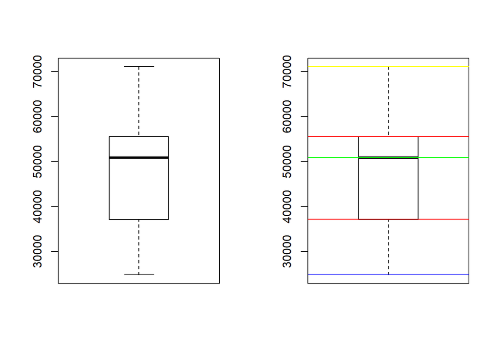

```r
par(mfrow = c(1, 2))
boxplot(crimemd$b_e)
boxplot(crimemd$b_e)


abline(h = min(crimemd$b_e), col = "Blue")

abline(h = max(crimemd$b_e), col = "Yellow")

abline(h = median(crimemd$b_e), col = "Green")

abline(h = quantile(crimemd$b_e, c(0.25, 0.75)), col = "Red")
```

## Line Graph for MD crimes

We can see that overall crimes in MD have gone steadily down since 1995, and are currently at its lowest in 40 years.

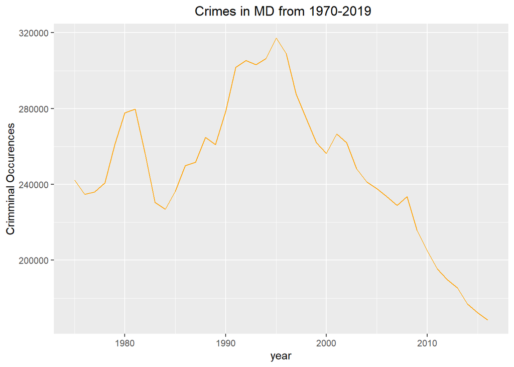

```r
plot<-ggplot(data=crimemd, aes(x=year, y=grand_total))+geom_line(color = 'orange')+labs(y="Crimminal Occurences", title=" Crimes in MD from 1970-2019")+theme(plot.title = element_text(hjust =0.5))
plot+theme(legend.position = "none")
```

## Line graph for overall % change in crimes

The sharp decrease in crimes in MD from 1980-1983 is seen through this graph. Almost a 20 percent difference in 5 years.

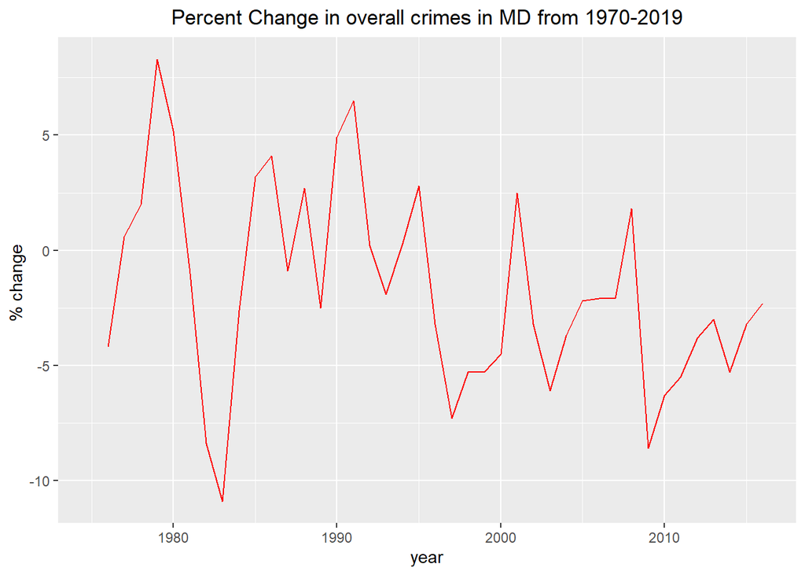

```r
plot<-ggplot(data=crimemd, aes(x=year, y=overall_percent_change))+geom_line(color = 'red')+labs(y="% change ", title="Percent Change in overall crimes in MD from 1970-2019")+theme(plot.title = element_text(hjust =0.5))
plot+theme(legend.position = "none")
```

## Line Graph for breaking and Entering

We can see that there was a sharp decrease in breaking and entering crimes in MD from 1980-1983.

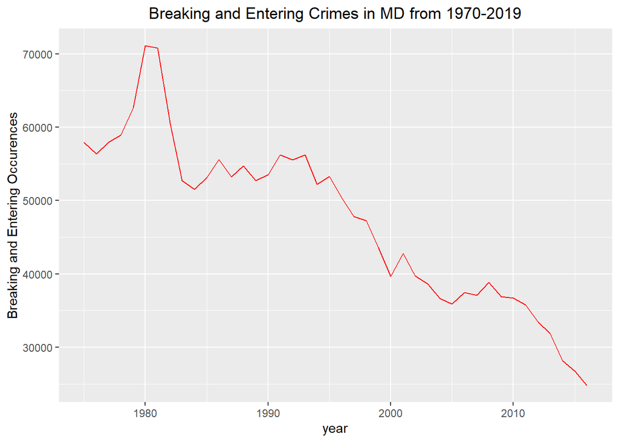

```r
plot<-ggplot(data=crimemd, aes(x=year, y=b_e))+geom_line(color = 'red')+labs(y="Breaking and Entering Occurences", title="Breaking and Entering Crimes in MD from 1970-2019")+theme(plot.title = element_text(hjust =0.5))
plot+theme(legend.position = "none")
```

## Line graph for percent change for breaking and entering

We can see that huge percentage change from 1980-1983 which leads me to believe a law or jurisdiction must have affected this. The same as well with 2000-2002 when there was that big percent increase.

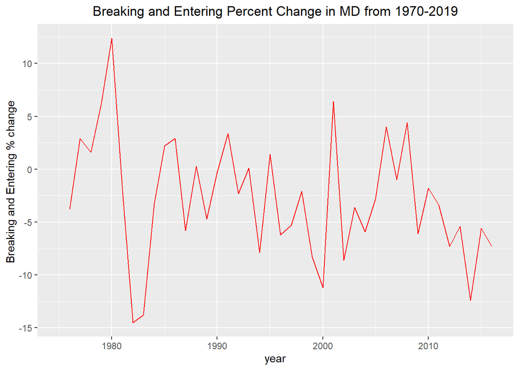

```r
plot<-ggplot(data=crimemd, aes(x=year, y=b_e_percent_change))+geom_line(color = 'red')+labs(y="Breaking and Entering % change ", title="Breaking and Entering Percent Change in MD from 1970-2019")+theme(plot.title = element_text(hjust =0.5))
plot+theme(legend.position = "none")
```